# A Robust Machine Learning Framework for Outcome-wide Exposome Data Analysis

# 15. APPROACH B UNPENALISED HEATMAPS

The unpenalised comparison shows all unpenalised estimates beside the post-bootstrap result, where only associations with `p_value < 0.05` are coloured. Grey denotes a masked association; stored model coefficients and result tables are not overwritten.

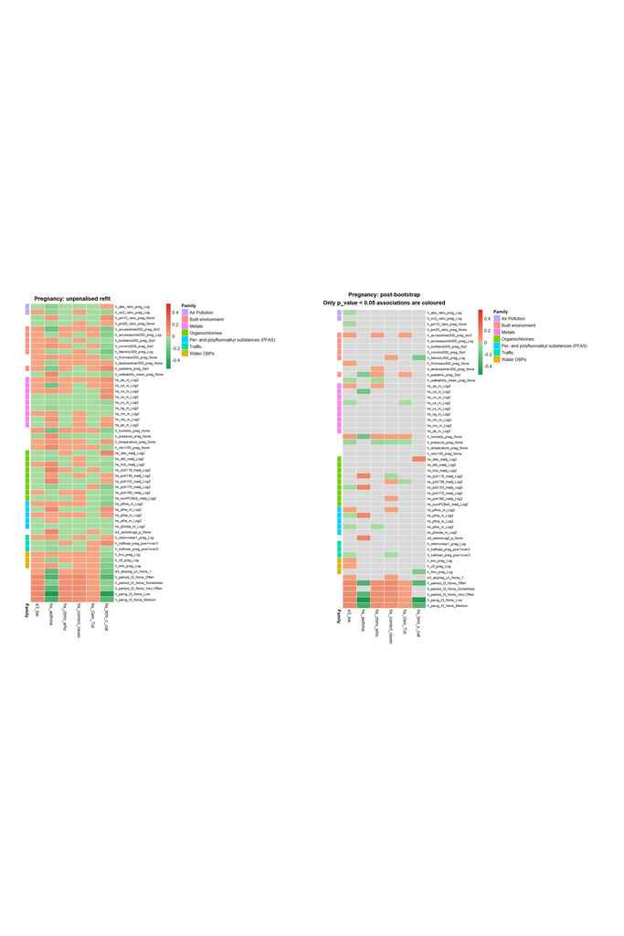

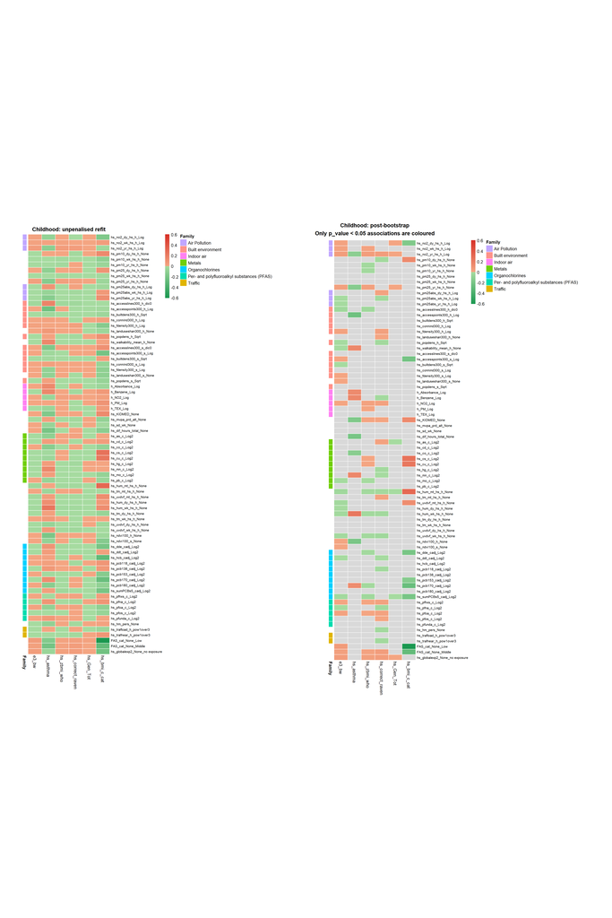

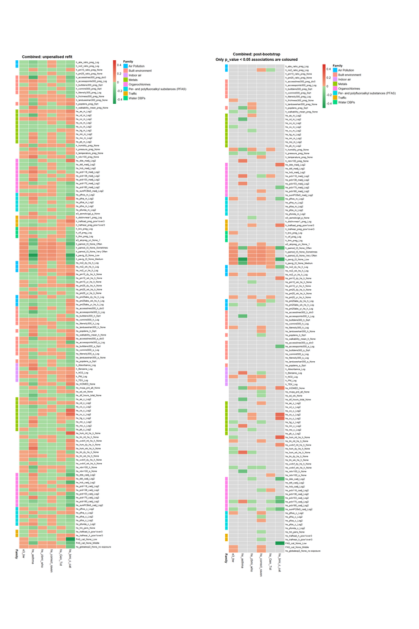

```r
# ==============================================================================
# BLOCK 15: APPROACH B UNPENALISED PRE- VS POST-BOOTSTRAP HEATMAPS
# ==============================================================================
# The right panel colours only coefficients with p_value < 0.05.
# Non-significant betas remain unchanged in model objects and CSV files; NA is
# used only in the temporary plotting matrix so those cells are not coloured.

# Plotting helper functions used throughout this block are defined in
# functions/msrrr_plotting_functions.R.

split_heatmaps_by_domain <- FALSE
unpenalized_heatmap_scenarios <- list(
  list(
    fit = fit_preg_unpenalized, results = res_preg_unpenalized,
    name = "Pregnancy"
  ),
  list(
    fit = fit_child_unpenalized, results = res_child_unpenalized,
    name = "Childhood"
  ),
  list(
    fit = fit_comb_unpenalized, results = res_comb_unpenalized,
    name = "Combined"
  )
)

unpenalized_pdf <- paste0(
  "results/UNPENALISED_PRE_vs_POST_BOOTSTRAP_EXPOSOME_SIGNATURES_",
  "wholesample.pdf"
)
unpenalized_pre_post_grobs <- list()
for (scenario in unpenalized_heatmap_scenarios) {
  family_pages <- character(0)
  if (split_heatmaps_by_domain) {
    family_pages <- unique(na.omit(
      get_heatmap_row_family(colnames(scenario$fit$X_selected))
    ))
  }
  if (length(family_pages) == 0L) {
    unpenalized_pre_post_grobs[[length(unpenalized_pre_post_grobs) + 1L]] <-
      plot_unpenalized_pre_post(
        scenario$fit, scenario$results, scenario$name, draw = FALSE
      )
  } else {
    for (family_page in family_pages) {
      unpenalized_pre_post_grobs[[length(unpenalized_pre_post_grobs) + 1L]] <-
        plot_unpenalized_pre_post(
          scenario$fit, scenario$results, scenario$name, family_page,
          draw = FALSE
        )
    }
  }
}
save_grobs_pdf(
  unpenalized_pre_post_grobs, unpenalized_pdf, width = 20, height = 26
)
message(">>> Unpenalised pre/post heatmaps exported to: ", unpenalized_pdf)

# Display the same unpenalised pre/post-bootstrap heatmaps in the HTML.
for (scenario in unpenalized_heatmap_scenarios) {
  grid::grid.newpage()
  plot_unpenalized_pre_post(
    scenario$fit, scenario$results, scenario$name
  )
}
```

```r
# SVG is a single-page format: export one editable file per scenario.
for (scenario_index in seq_along(unpenalized_heatmap_scenarios)) {
  scenario <- unpenalized_heatmap_scenarios[[scenario_index]]
  svg_file <- paste0(
    "results/UNPENALISED_PRE_vs_POST_BOOTSTRAP_",
    toupper(scenario$name), ".svg"
  )
  scenario_grob <- plot_unpenalized_pre_post(
    scenario$fit, scenario$results, scenario$name, draw = FALSE
  )
  save_grob_svg(scenario_grob, svg_file, width = 20, height = 26)
}
unpenalized_combined_svg <- sub("\\.pdf$", ".svg", unpenalized_pdf)
save_grob_svg(
  gridExtra::arrangeGrob(grobs = unpenalized_pre_post_grobs, ncol = 1),
  unpenalized_combined_svg, width = 20, height = 72
)
```

# 16. OPTIONAL APPROACH B UNPENALISED LOCO

The unpenalised LOCO analysis keeps the corresponding whole-sample-selected exposure subset fixed across every cohort exclusion and bootstrap. This keeps coefficient-by-coefficient comparisons aligned. As in penalised LOCO, continuous X/Z standardisation and continuous-outcome scaling are recalculated after excluding each cohort, while 0/1 dummy variables remain unchanged. This block defines its cohorts independently of the penalised LOCO block and exports its own significance/sign and pre- versus post-bootstrap LOCO plots.

```r
# BLOCK 16: OPTIONAL APPROACH B UNPENALISED LOCO SENSITIVITY ANALYSIS
# ==============================================================================
# This block deliberately fixes the whole-sample penalised exposure subset for
# every cohort exclusion and every bootstrap sample. It does not reselect
# exposures inside a LOCO subsample. Consequently, the resulting p-values and
# intervals remain conditional on the original whole-sample selection.
# This block creates its own cohort definitions and does not require the
# penalised LOCO block. The preprocessing helper functions themselves are
# sourced from functions/msrrr_tutorial_workflow_functions.R.
# It also exports its own LOCO significance/sign summaries and pre- versus
# post-bootstrap comparison plots.
# Computational cost: another 6 cohorts x 3 scenarios x n_boot_global fits.
# ==============================================================================
run_unpenalized_loco <- TRUE
run_unpenalized_loco_bootstrap <- TRUE

if (run_unpenalized_loco) {
  cohort_id <- as.character(covs_raw$h_cohort)
  if (length(cohort_id) != nrow(Y) ||
      nrow(X_preg) != nrow(Y) ||
      nrow(X_child) != nrow(Y) ||
      nrow(Z) != nrow(Y)) {
    stop(
      paste(
        "LOCO requires covs_raw, X_preg, X_child, Z and Y to contain",
        "the same participants in the same row order."
      )
    )
  }
  if (anyNA(cohort_id) || any(cohort_id == "")) {
    stop("h_cohort contains missing/empty values; LOCO membership is undefined.")
  }
  cohort_levels <- sort(unique(cohort_id))
  if (length(cohort_levels) < 2L) {
    stop("LOCO requires at least two observed cohorts.")
  }
  reference_cohort <- levels(as.factor(covs_raw$h_cohort))[1L]
  cohort_dummy_columns <- grep(
    "^h_cohort_", colnames(Z), value = TRUE
  )

  message(
    ">>> [Optional LOCO] Starting unpenalised LOCO with fixed ",
    "whole-sample-selected exposure subsets..."
  )
  unpenalized_loco_dir <- "results/LOCO_UNPENALISED"
  dir.create(unpenalized_loco_dir, recursive = TRUE, showWarnings = FALSE)

  unpenalized_loco_specifications <- list(
    Pregnancy = list(
      X_source = X_preg,
      whole_object = fit_preg_unpenalized
    ),
    Childhood = list(
      X_source = X_child,
      whole_object = fit_child_unpenalized
    ),
    Combined = list(
      X_source = cbind(X_preg, X_child),
      whole_object = fit_comb_unpenalized
    )
  )
  unpenalized_loco_fits <- setNames(
    vector("list", length(cohort_levels)), cohort_levels
  )
  unpenalized_loco_results <- setNames(
    vector("list", length(cohort_levels)), cohort_levels
  )

  for (omitted_cohort in cohort_levels) {
    keep_subject <- cohort_id != omitted_cohort
    message(
      ">>> [Optional unpenalised LOCO] Excluding cohort ", omitted_cohort,
      "; retaining ", sum(keep_subject), " participant(s)."
    )

    Z_loco_raw <- as.matrix(Z[keep_subject, , drop = FALSE])
    if (identical(omitted_cohort, reference_cohort)) {
      remaining_cohort_dummies <- intersect(
        cohort_dummy_columns, colnames(Z_loco_raw)
      )
      if (length(remaining_cohort_dummies) > 0L) {
        Z_loco_raw <- Z_loco_raw[
          , colnames(Z_loco_raw) != remaining_cohort_dummies[1L],
          drop = FALSE
        ]
      }
    }
    Z_loco <- scale_loco_matrix(
      Z_loco_raw, matrix_name = "Z", drop_constant = TRUE
    )
    Y_loco <- scale_loco_outcomes(Y[keep_subject, , drop = FALSE])
    unpenalized_loco_fits[[omitted_cohort]] <- list()
    unpenalized_loco_results[[omitted_cohort]] <- list()

    for (scenario_name in names(unpenalized_loco_specifications)) {
      scenario <- unpenalized_loco_specifications[[scenario_name]]
      selected_names <- colnames(scenario$whole_object$X_selected)
      X_loco_all <- scale_loco_matrix(
        scenario$X_source[keep_subject, , drop = FALSE],
        matrix_name = paste0("X (", scenario_name, ")"),
        drop_constant = FALSE
      )
      missing_selected <- setdiff(selected_names, colnames(X_loco_all))
      if (length(missing_selected) > 0L) {
        stop(
          "Selected exposure(s) missing from ", scenario_name, " LOCO data: ",
          paste(missing_selected, collapse = ", ")
        )
      }
      X_loco_selected <- X_loco_all[, selected_names, drop = FALSE]
      loco_rank <- min(
        scenario$whole_object$nrank,
        ncol(X_loco_selected),
        ncol(Y_loco)
      )

      fit_loco_unpenalized <- msrrr.fit(
        Y = Y_loco,
        X = X_loco_selected,
        Z = Z_loco,
        family = outcome_families,
        familygroup = family_mapping,
        nrank = loco_rank,
        lambda = 0,
        init = NULL,
        ensure_intercept = TRUE
      )
      rownames(fit_loco_unpenalized$B) <- selected_names
      colnames(fit_loco_unpenalized$B) <- colnames(Y_loco)
      unpenalized_object_loco <- list(
        fit = fit_loco_unpenalized,
        X_selected = X_loco_selected,
        nrank = loco_rank,
        lambda = 0
      )
      unpenalized_loco_fits[[omitted_cohort]][[scenario_name]] <-
        unpenalized_object_loco

      if (run_unpenalized_loco_bootstrap) {
        inference_loco <- run_unpenalized_bootstrap(
          unpenalized_object = unpenalized_object_loco,
          Y = Y_loco,
          Z = Z_loco,
          family = outcome_families,
          familygroup = family_mapping,
          n_boot = n_boot_global,
          scenario_name = paste0(
            scenario_name, " without cohort ", omitted_cohort
          ),
          show_progress = FALSE
        )
        inference_loco$omitted_cohort <- omitted_cohort
        inference_loco$scenario <- scenario_name
        unpenalized_loco_results[[omitted_cohort]][[scenario_name]] <-
          inference_loco
        write.csv2(
          inference_loco,
          file.path(
            unpenalized_loco_dir,
            paste0(
              "UNPENALISED_LOCO_INFERENCE_", toupper(scenario_name),
              "_WITHOUT_COHORT_", omitted_cohort, ".csv"
            )
          ),
          row.names = FALSE
        )
      }
    }
  }
```

```r
  unpenalized_loco_summaries <- list()
  unpenalized_loco_pre_summaries <- list()
  for (scenario_name in names(unpenalized_loco_specifications)) {
    selected_names <- colnames(
      unpenalized_loco_specifications[[scenario_name]]$whole_object$X_selected
    )
    outcome_names <- colnames(Y_whole)
    n_significant <- n_positive <- n_negative <- matrix(
      0L, nrow = length(selected_names), ncol = length(outcome_names),
      dimnames = list(selected_names, outcome_names)
    )
    n_fitted <- n_fitted_positive <- n_fitted_negative <- matrix(
      0L, nrow = length(selected_names), ncol = length(outcome_names),
      dimnames = list(selected_names, outcome_names)
    )
    for (omitted_cohort in cohort_levels) {
      if (run_unpenalized_loco_bootstrap) {
        result <- unpenalized_loco_results[[omitted_cohort]][[scenario_name]]
        row_index <- match(result$exposure, selected_names)
        col_index <- match(result$outcome, outcome_names)
        valid <- !is.na(row_index) & !is.na(col_index) & result$significant
        for (i in which(valid)) {
          n_significant[row_index[i], col_index[i]] <-
            n_significant[row_index[i], col_index[i]] + 1L
          if (result$beta_unpenalized[i] > 0) {
            n_positive[row_index[i], col_index[i]] <-
              n_positive[row_index[i], col_index[i]] + 1L
          } else if (result$beta_unpenalized[i] < 0) {
            n_negative[row_index[i], col_index[i]] <-
              n_negative[row_index[i], col_index[i]] + 1L
          }
        }
      }
      fitted_B <- as.matrix(
        unpenalized_loco_fits[[omitted_cohort]][[scenario_name]]$fit$B
      )
      rownames(fitted_B) <- selected_names
      colnames(fitted_B) <- outcome_names
      fitted_selected <- abs(fitted_B) > selection_tol
      n_fitted <- n_fitted + fitted_selected
      n_fitted_positive <- n_fitted_positive +
        (fitted_selected & fitted_B > 0)
      n_fitted_negative <- n_fitted_negative +
        (fitted_selected & fitted_B < 0)
    }
    unpenalized_loco_pre_summaries[[scenario_name]] <- list(
      n_selected = n_fitted,
      n_positive = n_fitted_positive,
      n_negative = n_fitted_negative
    )
    if (run_unpenalized_loco_bootstrap) {
      summary_long <- expand.grid(
        exposure = selected_names,
        outcome = outcome_names,
        KEEP.OUT.ATTRS = FALSE,
        stringsAsFactors = FALSE
      )
      summary_long$n_significant_loco <- as.vector(n_significant)
      summary_long$n_positive_significant <- as.vector(n_positive)
      summary_long$n_negative_significant <- as.vector(n_negative)
      unpenalized_loco_summaries[[scenario_name]] <- list(
        summary = summary_long,
        n_selected = n_significant,
        n_positive = n_positive,
        n_negative = n_negative
      )
      write.csv2(
        summary_long,
        file.path(
          unpenalized_loco_dir,
          paste0(
            "UNPENALISED_LOCO_SIGNIFICANCE_SUMMARY_",
            toupper(scenario_name), ".csv"
          )
        ),
        row.names = FALSE
      )
    }
  }

  # Always export the unpenalised LOCO fits before bootstrap. This output is
  # available even when run_unpenalized_loco_bootstrap = FALSE.
  unpenalized_loco_pre_pdf <- file.path(
    unpenalized_loco_dir,
    "UNPENALISED_LOCO_SELECTION_AND_SIGN_SUMMARY.pdf"
  )
  unpenalized_loco_pre_grobs <- list()
  for (scenario_name in names(unpenalized_loco_pre_summaries)) {
    unpenalized_loco_pre_grobs[[scenario_name]] <-
      plot_penalized_loco_summary(
        unpenalized_loco_pre_summaries[[scenario_name]],
        scenario_name,
        selection_definition = paste0("abs(beta) > ", selection_tol),
        method_label = "unpenalised LOCO - Pre-bootstrap",
        draw = FALSE
      )
  }
  save_grobs_pdf(
    unpenalized_loco_pre_grobs, unpenalized_loco_pre_pdf, 14, 30
  )
  for (scenario_name in names(unpenalized_loco_pre_summaries)) {
    save_grob_svg(
      unpenalized_loco_pre_grobs[[scenario_name]],
      file.path(
        unpenalized_loco_dir,
        paste0(
          "UNPENALISED_LOCO_SELECTION_", toupper(scenario_name), ".svg"
        )
      ),
      width = 14, height = 30
    )
  }

  # The following significance and pre/post outputs require bootstrap results.
  if (run_unpenalized_loco_bootstrap) {
  unpenalized_loco_pdf <- file.path(
    unpenalized_loco_dir,
    "UNPENALISED_LOCO_SIGNIFICANCE_AND_SIGN_SUMMARY.pdf"
  )
  unpenalized_loco_grobs <- list()
  for (scenario_name in names(unpenalized_loco_summaries)) {
    unpenalized_loco_grobs[[scenario_name]] <- plot_penalized_loco_summary(
      unpenalized_loco_summaries[[scenario_name]],
      scenario_name,
      selection_definition = "p_value < 0.05",
      method_label = "unpenalised LOCO",
      draw = FALSE
    )
  }
  save_grobs_pdf(unpenalized_loco_grobs, unpenalized_loco_pdf, 14, 30)
  for (scenario_name in names(unpenalized_loco_summaries)) {
    save_grob_svg(
      unpenalized_loco_grobs[[scenario_name]],
      file.path(
        unpenalized_loco_dir,
        paste0(
          "UNPENALISED_LOCO_SIGNIFICANCE_", toupper(scenario_name), ".svg"
        )
      ),
      width = 14, height = 30
    )
  }

  save_grob_svg(
    gridExtra::arrangeGrob(grobs = unpenalized_loco_grobs, ncol = 1),
    sub("\\.pdf$", ".svg", unpenalized_loco_pdf),
    width = 14, height = 90
  )

  unpenalized_loco_pre_post_pdf <- file.path(
    unpenalized_loco_dir,
    "UNPENALISED_LOCO_PRE_vs_POST_BOOTSTRAP_SUMMARY.pdf"
  )
  unpenalized_loco_pre_post_grobs <- list()
  for (scenario_name in names(unpenalized_loco_summaries)) {
    common_rows <- rownames(
      unpenalized_loco_pre_summaries[[scenario_name]]$n_selected
    )[
      rowSums(
        unpenalized_loco_pre_summaries[[scenario_name]]$n_selected > 0L |
          unpenalized_loco_summaries[[scenario_name]]$n_selected > 0L
      ) > 0L
    ]
    pre_grob <- plot_penalized_loco_summary(
      unpenalized_loco_pre_summaries[[scenario_name]], scenario_name,
      selection_definition = "coefficient differs from zero",
      method_label = "Pre-bootstrap", rows_to_plot = common_rows,
      cellwidth = 32, cellheight = 13, draw = FALSE
    )
    post_grob <- plot_penalized_loco_summary(
      unpenalized_loco_summaries[[scenario_name]], scenario_name,
      selection_definition = "p_value < 0.05",
      method_label = "Post-bootstrap", rows_to_plot = common_rows,
      cellwidth = 32, cellheight = 13, draw = FALSE
    )
    comparison_grob <- gridExtra::arrangeGrob(
      pre_grob, grid::nullGrob(), post_grob, ncol = 3,
      widths = grid::unit.c(
        grid::unit(1, "null"), grid::unit(0.25, "in"),
        grid::unit(1, "null")
      ),
      top = grid::textGrob(
        paste0(scenario_name, " — unpenalised LOCO sensitivity"),
        gp = grid::gpar(fontface = "bold", fontsize = 14)
      )
    )
    unpenalized_loco_pre_post_grobs[[scenario_name]] <- comparison_grob
    svg_name <- file.path(
      unpenalized_loco_dir,
      paste0(
        "UNPENALISED_LOCO_PRE_vs_POST_BOOTSTRAP_",
        toupper(scenario_name), ".svg"
      )
    )
    save_grob_svg(comparison_grob, svg_name, 22, 30)
  }
  save_grobs_pdf(
    unpenalized_loco_pre_post_grobs,
    unpenalized_loco_pre_post_pdf,
    22, 30
  )
```

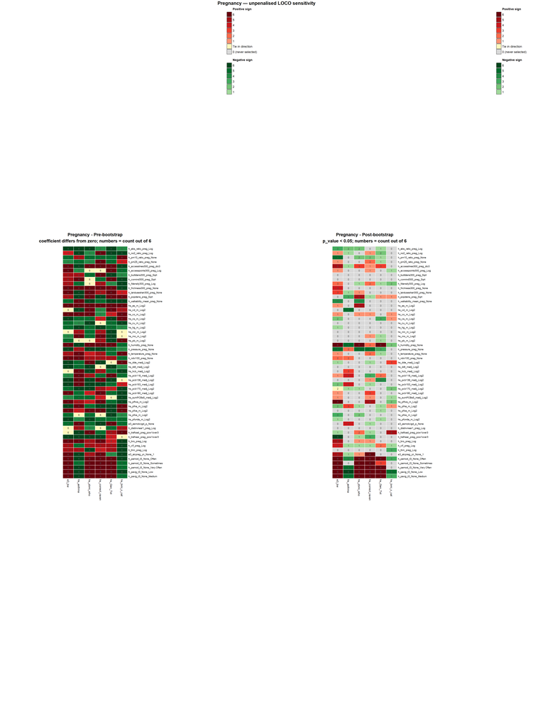

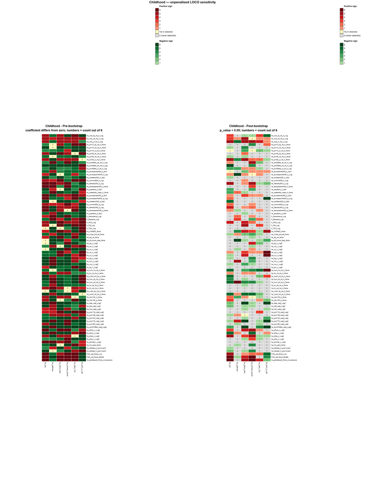

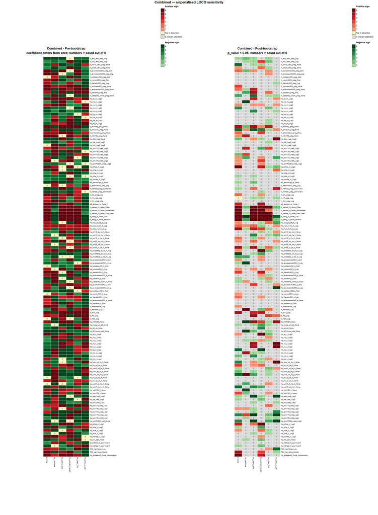

```r
  # Show only the paired comparison in the HTML.
  for (scenario_name in names(unpenalized_loco_pre_post_grobs)) {
    grid::grid.newpage()
    grid::grid.draw(unpenalized_loco_pre_post_grobs[[scenario_name]])
  }
  }

  save(
    unpenalized_loco_fits,
    unpenalized_loco_results,
    unpenalized_loco_summaries,
    unpenalized_loco_pre_summaries,
    file = file.path(
      unpenalized_loco_dir, "UNPENALISED_LOCO_RESULTS.RData"
    )
  )
  message(
    ">>> [Optional LOCO] Unpenalised results saved under: ",
    unpenalized_loco_dir
  )
}
```

```r
# ==============================================================================
```

# 17. METHODOLOGICAL SUMMARY

| Approach | Primary quantities | Appropriate interpretation |
| --- | --- | --- |
| **Penalised bootstrap stability** | `sel_prob`, `sign_consistency`, penalised beta | Stable sparse associations under resampling; not classical significance |
| **Conditional unpenalised inference** | Unpenalised beta, bootstrap SE, 95% CI, p-value | Approximate inference conditional on the whole-sample selection step |
| **LOCO sensitivity** | Number of cohort exclusions meeting the relevant criterion and dominant sign | Sensitivity of conclusions to omission of any one cohort |

The two post-selection approaches answer different questions. A real analysis should pre-specify its primary approach and should not require an association to pass both.

# 18. FINAL RECOMMENDATIONS

## For analysis and reporting

1. Pre-specify and report the chosen post-selection approach.
   - If Approach A is chosen, report the selection-probability and sign-consistency thresholds.
   - If Approach B is chosen, describe its p-values and intervals as conditional on the preceding exposure-selection step.
2. Document the rank/lambda grids, selected values, warm-start setting and configured coefficient-selection tolerance.
3. Review the scenario-specific `msrrr_cv()` diagnostics, including whether the selected rank or lambda lies on a tested boundary.
4. State that continuous X/Z columns were standardised while 0/1 dummy variables remained on their original scale.
5. Report the missing-data strategy.
6. Report whether LOCO was performed and use it to identify conclusions that may be sensitive to a particular cohort.
7. Treat threshold changes as pre-specified sensitivity analyses, not as a way to search for preferred results.

## Remaining methodological decision

Pregnancy, Childhood and Combined currently share the same stability thresholds; outcome correlation alone is not a calibrated threshold rule.

# APPENDIX: Quick Reference

**Three-Stage Protocol:**

```
Stage 1: Stratified 80/20 Split (prevent rare disease imbalance)
         ↓
Stage 2: 5-Fold CV on training (optimize rank & lambda)
         ↓
Stage 3: Whole-sample refit + bootstrap
         (100 resamples in this tutorial; 500 recommended for final analyses)
```

**Post-selection Bootstrap Summaries:**

```
Approach A:
  Current working thresholds: sel_prob >= 0.90 and sign_consistency >= 0.80
  These are not guaranteed universal cut-offs; simulation work is ongoing to
  assess suitable thresholds across different data structures and settings.

Approach B:
  fixed whole-sample-selected exposure subset
  lambda = 0
  bootstrap standard error, approximate p-value and 95% interval for each
  exposure–outcome coefficient
```